# Project 2: Public Health & Epidemiology

Merrimack College DSE6630: Healthcare & Life Sciences Analytics

Katherine S. Geist, PhD

1 June 2026

It is **September of 2020**, right in the middle of the COVID-19 pandemic and during the California statewide shutdown. You have just been hired by the [California Department of Public Health (CDPH) in Vital Records](https://www.cdph.ca.gov/Programs/CHSI/Pages/Vital-Records.aspx) to track non-COVID mortality trends for the past 4 years for which all data have currently been aggregated and de-identified (anonymized). You are told that the purpose is two-fold:

1. **Help the state identify shifts in spatiotemporal mortality trends as a result of the COVID statewide stay-at-home orders.**
2. **Help the state build predictive models for non-COVID causes of mortality to establish a pre-COVID baseline.**

## 1.1 Provided data: California mortalities

You were given properly de-identified data from 2017 - 2020, which contain mortality records for the state of California by gender, leading cause of death, race / ethnicity, and location of death. All data have been taken from the death certificates filed with the state.

**NOTE**: If you are interested in these data, the source is the [California Death Profiles dataset](https://data.chhs.ca.gov/dataset/death-profiles-by-county) maintained by California Health and Human Services.

```r
## Load the provided data files
load("california_mortality_tables.RData")
```

You are provided 6 tables total, which have the following variables.

Table 1. Data dictionary of variables in the California mortality tables.

| **All Tables** |  |
| --- | --- |
| Year | Year of record |
| Month | Month of record |
| County | California county where death was recorded |
| **Annual Mortality Table** |  |
| annualCount | Number of deaths for the sex specified |
| raceEthnicity | Race and/or Ethnicity of the deceased; Latinx is unfortunately treated as a racial category here rather than an ethnic group |
| **Specialized Variables** |  |
| leadingCauseDeath | Leading cause of death per death certificate; See separate table for encoding |
| ageBins | Age groups where the age at death was known |
| ageDeaths | Number of deaths for the age bin specified |
| biologicalSex | Biological sex of decedent |
| sexDeaths | Number of deaths for the sex specified |
| placeDeathOccurred | Location of death, per death certificate |
| placeDeaths | Number of deaths matching specified criteria |
| raceDeaths | Number of deaths matching race / ethnic criteria |
| totalDeaths | Number of deaths per month, year, & county |

Table 2. Underlying cause of death category based on coding using the Tenth Revision of the International Classification of Diseases (ICD) codes

| 3-letter Code | Description | ICD-10 Codes |
| --- | --- | --- |
| HTD | Diseases of the Heart | I00-I09, I11, I13, I20-I51 |
| CAN | Malignant Neoplasms (Cancers) | C00-C97 |
| STK | Cerebrovascular Disease (Stroke) | I60-I69 |
| CLD | Chronic Lower Respiratory Disease (CLRD) | J40-J47 |
| INJ | Unintentional Injuries | V01-X59, Y85-Y86 |
| PNF | Pneumonia and Influenza | J09-J18 |
| DIA | Diabetes Mellitus | E10-E14 |
| ALZ | Alzheimer’s Disease | G30 |
| LIV | Chronic Liver Disease and Cirrhosis | K70, K73-K74 |
| SUI | Intentional Self Harm (Suicide) | U03, X60-X84, Y87.0 |
| HYP | Essential Hypertension and Hypertensive Renal Disease | I10, I12, I15 |
| HOM | Homicide | U01-U02, X85-Y09, Y87.1 |
| NEP | Nephritis, Nephrotic Syndrome and Nephrosis | N00-N07, N17-N19, N25-N27] |
| OTH | All Other Causes of Death | All codes not listed above |

**NOTE**: Make sure to refer to these tables as you go!

# 2 Using Spatial Analysis to Assess Spatiotemporal Trends in Overall Mortality

## 2.1 Background

Unlike your first project, your data engineering team (i.e., **me**) has provided you with most of the data tables in a nice, tidy format that are relatively nice and tidy to begin with - which means you can dig right into the analysis! Remember, any time you have datasets with **spatial information** they are spatial data; these data are organized by California county, so you know you must do a spatial analysis! However, there is also a *temporal* element - you have data from four different years, 2017 to 2020. So, you decide you will make maps to analyze both the spatial (geographic) and temporal (time) trends in the hope it will shed insight into which downstream analysis you should do. Consider this to be part of your **Exploratory Data Analysis**.

As discussed in lecture, one of the key types of spatial data files you might use are called **shapefiles**, which is what you are going to practice loading and working with shapefiles, using this [open source dataset](https://gis.data.ca.gov/datasets/2c4e32ee61824e28bd4cf37ecac96f39_0/explore?location=37.271891%2C-119.270269%2C5) for the state of California. You will have to download these data as they are too large to put onto GitHub. **NOTE**: Make sure you download the shapefiles only and decompress them!

Begin by downloading the requisite spatial data files. Make sure you put them in their own directory called **California_County_Boundaries2025** on your Desktop; otherwise, you will need to adjust your path in the file settings below! This is similar to what I had you do in Demo 1, if you’ll recall.

Notice that the directory contains six files, three of them with file extensions you discussed last week in lecture:

- `California_County_Boundary.cpg`
- `California_County_Boundary.dbf`
- `California_County_Boundary.prj`
- `California_County_Boundary.shp`
- `California_County_Boundary.shp.xml`
- `California_County_Boundary.shx`

#### Question 1 [1 point]:

What do each of these six files represent? You will not be able to open them directly on your computer, so you may need to refer back to lecture and do a little digging to figure out the type of data you would expect each of these files to contain.

> A shapefile is not a single file but a collection of files that work together to store and manage geographic information. Each file serves a different purpose.

> .shp: Contains the actual geographic features and geometry data. In this project, it stores the county boundary shapes used to draw the California map. .dbf: Stores attribute information associated with each geographic feature. Such as county names, identifiers, and other county-level variables. .shx: Serves as an index file for the shapefile. It allows GIS software to quickly locate and retrieve geographic features stored in the .shp file. .prj: Contains projection and coordinate reference system information. This ensures that the county boundaries are positioned correctly on the Earth and align properly with other spatial datasets. .cpg: Stores character encoding information used for text fields in the dataset. This helps ensure that county names and other text data are displayed correctly. .shp.xml: Contains metadata describing the dataset, such as information about its source, creation, structure, and intended use.

> Together, these files allow geographic data to be accurately stored, displayed, and analyzed within GIS and spatial analysis software.

## 2.2 Your objective

You want to first get a sense for **annual trends** in overall mortality across the state to see what you are working with. Your first objective is to join your overall mortality data to the shapefile to be able to make maps to visualize these trends. You also want to calculate **spatial weights** to allow you to create predictive models of mortality by county.

## 2.3 Making your first map of California

You are going to practice two ways to make maps from shapefiles so that you can see two ways to do it. Also, to give you more for reference, you are roughly following the GIS Basics Chapter of the Epi R Handbook (with your own twist, of course!). This chapter may be helpful for understanding more of the “nuts and bolts” of GIS as well, including definitions and why you might do things certain ways.

**The initial processing steps will include:**

1. Import the shapefile
2. Filter rows to keep only areas of interest
3. Merge with the other data tables to creates maps and analyze trends

### 2.3.1 Read in the shapefile & validate geometries

You will leverage the `read_sf()` function that is part of the `sf` package. As you might have guessed, `sf` refers to **shapefile**. Note that there is an alternative method to read in shapefiles called `st_read`, which is an alias for `read_sf()` with some different default arguments. By default, `read_sf()` is quiet, whereas `read_st()` will print information about the data source by default. Additionally, `read_sf()` returns a tibble rather than a dataframe. So which to choose? It’s your preference, in this case. By default, your code below will use `read_sf()` but you could instead use `read_st()` if you wanted.

```r
cali_sf <- read_sf("~/Desktop/Merrimack_DSE6630/Team_Directories/alpha/Module_Projects/Project_2/alifornia_County_Boundaries2025")

## Alternatively, you can read in the shapefile using the 'st_read()' function
## cali_st <- st_read("~/Downloads/California_County_Boundaries2025/California_County_Boundary.shp")
```

**NOTE** If you get a warning (as opposed to a critical error) is from [GDAL](https://gdal.org/en/stable/), a library of raster and vector geospatial data formats that your `read_sf()` (or `st_read()`) functions are using to transform the polygons for mapping. This warning indicates that some polygon geometries in the shapefile have boundaries (rings) with an inconsistent order of coordinates (“invalid winding order”). GIS tools assume that it will read from the right-hand, and the warning is letting you know that it is autocorrecting it. However, you could still have issues and it isn’t ideal.

*Just as you did in Demo 2, you can fix this by validating the polygon boundaries:*

```r
## Disable Google S2 engine
sf_use_s2(FALSE)
## Validate the geometry boundaries/edges
cali_sf <- st_make_valid(cali_sf)
```

*Now, let’s do a quick check of the map of California counties to make sure all the layers look okay:*

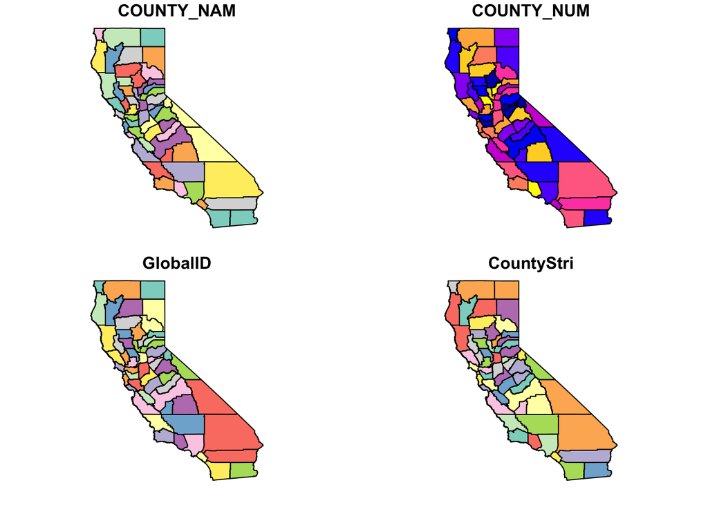

```r
plot(cali_sf)
```

*And let’s check the validity of the boundaries:*

```r
st_is_valid(cali_sf)
```

```
##  [1] TRUE TRUE TRUE TRUE TRUE TRUE TRUE TRUE TRUE TRUE TRUE TRUE TRUE TRUE TRUE
## [16] TRUE TRUE TRUE TRUE TRUE TRUE TRUE TRUE TRUE TRUE TRUE TRUE TRUE TRUE TRUE
## [31] TRUE TRUE TRUE TRUE TRUE TRUE TRUE TRUE TRUE TRUE TRUE TRUE TRUE TRUE TRUE
## [46] TRUE TRUE TRUE TRUE TRUE TRUE TRUE TRUE TRUE TRUE TRUE TRUE TRUE TRUE
```

```r
print(cali_sf$COUNTY_NAM)
```

```
##  [1] "Alpine"          "Amador"          "Butte"           "Calaveras"
##  [5] "Colusa"          "Contra Costa"    "Del Norte"       "El Dorado"
##  [9] "Fresno"          "Glenn"           "Humboldt"        "Imperial"
## [13] "Inyo"            "Kern"            "Kings"           "Lake"
## [17] "Lassen"          "Los Angeles"     "Madera"          "Marin"
## [21] "Mariposa"        "Mendocino"       "Merced"          "Modoc"
## [25] "Mono"            "Monterey"        "Napa"            "Nevada"
## [29] "Orange"          "Placer"          "Plumas"          "Riverside"
## [33] "Sacramento"      "San Benito"      "San Bernardino"  "San Diego"
## [37] "San Francisco"   "San Joaquin"     "San Luis Obispo" "San Mateo"
## [41] "Santa Barbara"   "Santa Clara"     "Santa Cruz"      "Shasta"
## [45] "Sierra"          "Siskiyou"        "Solano"          "Sonoma"
## [49] "Stanislaus"      "Sutter"          "Tehama"          "Trinity"
## [53] "Tulare"          "Tuolumne"        "Ventura"         "Yolo"
## [57] "Yuba"            "Alameda"         "Colusa"
```

```r
nrow(cali_sf)
```

```
## [1] 59
```

```r
length(unique(cali_sf$COUNTY_NAM))
```

```
## [1] 58
```

#### Question 2 [1 point]:

**Hint 1**: Are all of them counties? Try running `print(calif_sf$COUNTY_NAME)`. What do you see?

> The st_is_valid() function checks whether each geometry feature in the shapefile is valid and returns either TRUE or FALSE for each feature. In our shapefile, TRUE printed 59 times because there are 59 geometry features and all of them were valid after running st_make_valid(). The 59 features do not represent 59 unique counties. When we checked the county names, there were only 58 unique counties. This means that at least one county is represented by more than one geometry feature. In GIS data, a single county can sometimes be stored as multiple polygons if it contains disconnected geographic areas. Therefore, the number of geometry features can be larger than the number of unique counties.

*Next, let’s take a look at the geometry of the shapefile that you loaded.*

```r
cali_sf$geometry
```

```
## Geometry set for 59 features
## Geometry type: GEOMETRY
## Dimension:     XY
## Bounding box:  xmin: -13849230 ymin: 3833650 xmax: -12704990 ymax: 5162402
## Projected CRS: WGS 84 / Pseudo-Mercator
## First 5 geometries:
```

Notice that, just like Demo 2, you only have the **polygon** geometry in your shapefile. If you were to investigate further, you would find that currently there are no other geometries (e.g., lines or points) in this shapefile. You could add them and export the shapefile, if you ever needed to do so, like to share with someone else. For example, if you wanted to add points for the county seats of each county, you could add them based on longitude and latitude; similarly, you could add just points for major California cities, which I will demonstrate below.

#### Question 3A [0.5 points]:

What is the bounding box that comes with your shapefile and what does it tell us? **What would you do to the bounding box if you wanted to zoom in or out on a geographic feature?**

> The bounding box is the smallest rectangular area that contains all of the geographic features in the shapefile. For this dataset, the bounding box is defined by xmin = -13849230, ymin = 3833650, xmax = -12704990, and ymax = 5162402. These values represent the minimum and maximum x- and y-coordinates of the California county boundaries and define the overall spatial extent of the map. The bounding box tells us how much geographic area is covered by the shapefile and where the features are located within the coordinate system. If we wanted to zoom in on a specific geographic feature, we would decrease the size of the bounding box by narrowing the coordinate ranges. If we wanted to zoom out, we would increase the coordinate ranges so that a larger geographic area is displayed.

#### Question 3B [0.5 points]:

What is the projection? What does it tell you and why does projection matter? **What will change if you change the projection?**

> The projection for this shapefile is WGS 84 / Pseudo-Mercator. A projection is a mathematical method used to represent the Earth’s curved surface on a flat map. The projection determines how geographic coordinates are translated into map coordinates and how spatial features are displayed. Projection matters because different projections can distort distance, area, shape, or direction. Spatial analyses such as calculating distances, areas, and spatial relationships depend on the coordinate system being used. If an inappropriate projection is selected, the results of the analysis may be inaccurate. If the projection is changed, the actual county boundaries do not change, but their coordinate values and appearance on the map may change. Different projections emphasize different geographic properties, such as preserving area, shape, or distance, which can affect how the data are visualized and analyzed.

### 2.3.2 Create a basic map of California

In Demo 2, I showed you how to plot shapefiles using `ggplot2`’s `geom_sf()` function, and even though there are advanced mapping functions in R you could use you will stick with that for consistency, convenience, and speed.

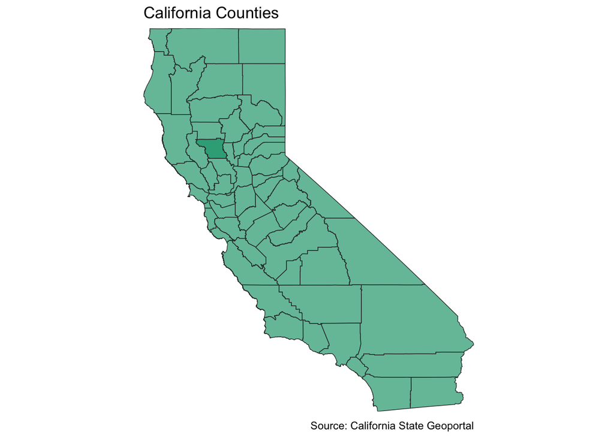

```r
## Initiate the plot and tell it the dataset
ggplot(data = cali_sf) +
  ## Give it specific fill and border colors
  geom_sf(fill = skittles[6],
          color = "gray20",
          linewidth = 0.25,
          alpha = 0.65) +

  ## Set map projection explicitly
  coord_sf(expand = FALSE) +   ## <- keeps map tight to its bounding box

  ## Uncomment to make a completely blank map background
   theme(
     panel.grid = element_blank(),
     panel.background = element_rect(fill = "white"),
     plot.background = element_rect(fill = "white"),
     axis.text = element_blank(),
     axis.ticks = element_blank(),
     axis.title = element_blank(),
   ) +

  ## Give it a title and footnote/caption
  labs(title = "California Counties",
       caption = "Source: California State Geoportal")
```

### 2.3.3 Zooming in on the map

Now, what if you only wanted to visualize a few counties? Let’s look at the three northernmost counties that border Oregon. The three northernmost California counties that border Oregon are:

- Del Norte
- Siskiyou
- Modoc

Notice that the county names are accessible through `cali_sf$COUNTY_NAM`. Thus, you can just use the `filter()` function from `dplyr` to be able to grab the three northernmost counties you want by name, which I have started for you.

#### Question 4 [1 point]:

Finish the code below to create a map of the northernmost 3 counties in California. You can copy and paste, with minor modifications, the code for the entire state map to do this. **NOTE** that you are storing your map into `map1`. This is because I will show you how to add labels in the next section! Don’t forget to update your plot title for full credit!

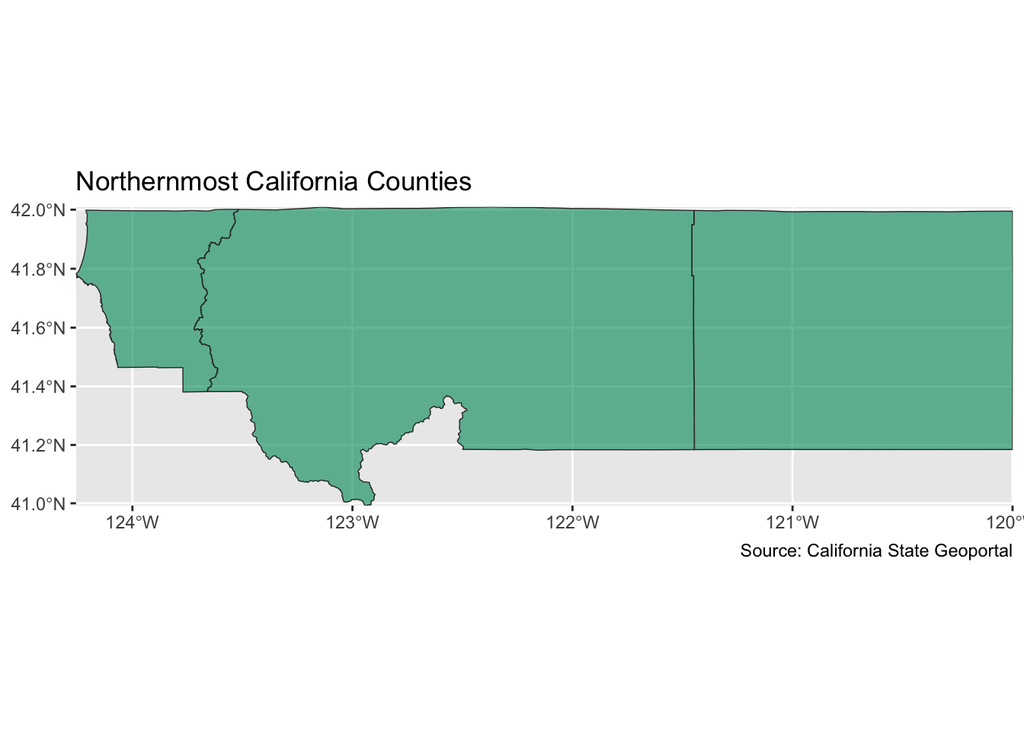

```r
# ## Start from the California spatial tibble - Uncomment to run
 map1 <- cali_sf %>%
#   ## Filter to just the 3 counties that border Oregon - Uncomment to run
   filter(COUNTY_NAM == "Del Norte" | COUNTY_NAM == "Siskiyou" | COUNTY_NAM == "Modoc") %>%

## YOUR CODE HERE.
  ggplot() +
  geom_sf(
    fill = skittles[6],
    color = "gray20",
    linewidth = 0.25,
    alpha = 0.65
  ) +
  coord_sf(expand = FALSE) +
  labs(
    title = "Northernmost California Counties",
    caption = "Source: California State Geoportal"
  )

map1
```

*Now let’s add labels!* This code will not run unless you have made `map1` correctly!

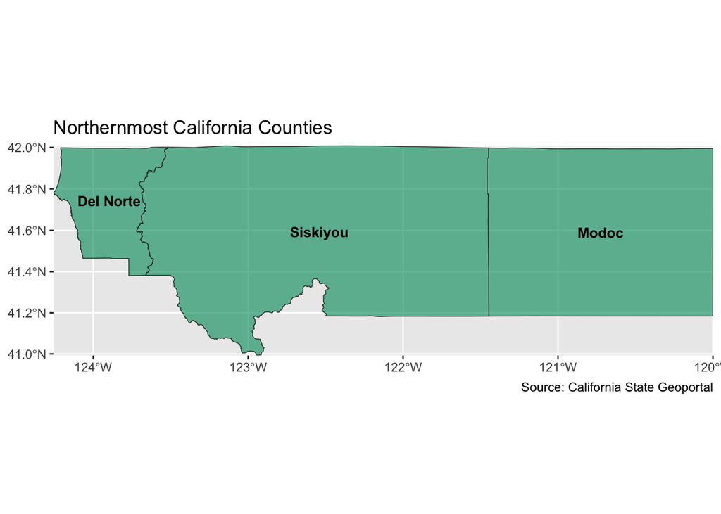

```r
### UNCOMMENT THIS CODE TO RUN:

# ## Calculate the county centers:
 county_centroids <- st_centroid(cali_sf) %>%
# ## Filter for just the northern centroids
     filter(COUNTY_NAM == "Del Norte" | COUNTY_NAM == "Siskiyou" | COUNTY_NAM == "Modoc")
#
# ## Now, add the labels to the map:
 map1 + geom_sf_text(data = county_centroids,
                     aes(label = COUNTY_NAM),
                    size = 3.5, fontface = "bold") +
   ## fix the x and y axis labels to make a beautiful map!
   theme(axis.title = element_blank())
```

## 2.3.4 Creating points for major cities in California

- Sacramento (the capital)
- Los Angeles
- San Diego
- San Francisco

But, to do this, it takes a little sorcery. You have to create a second **layer** for the points you want to overlay. So, you will put the longitude and latitude for each city, with the city’s name and an identifier as to whether it’s the capital or not, into its own dataframe. You will then convert it to a shapefile object.

```r
## Create a cities data frame with coordinates
cities <- data.frame(
  city = c("Sacramento", "San Diego", "Los Angeles", "San Francisco"),
  lon = c(-121.4944, -117.1611, -118.2437, -122.4194),
  lat = c(38.5816, 32.7157, 34.0522, 37.7749),
  cityType = c("capital", "major", "major", "major")
)

## Convert to shapefile object with the same projection as what you had
cities_sf <- st_as_sf(cities, coords = c("lon", "lat"), crs = 4326)
```

*Now, you can plot the map by overlaying the city points, with differing colors for each city and a different shape and size marker for the capital, Sacramento:*

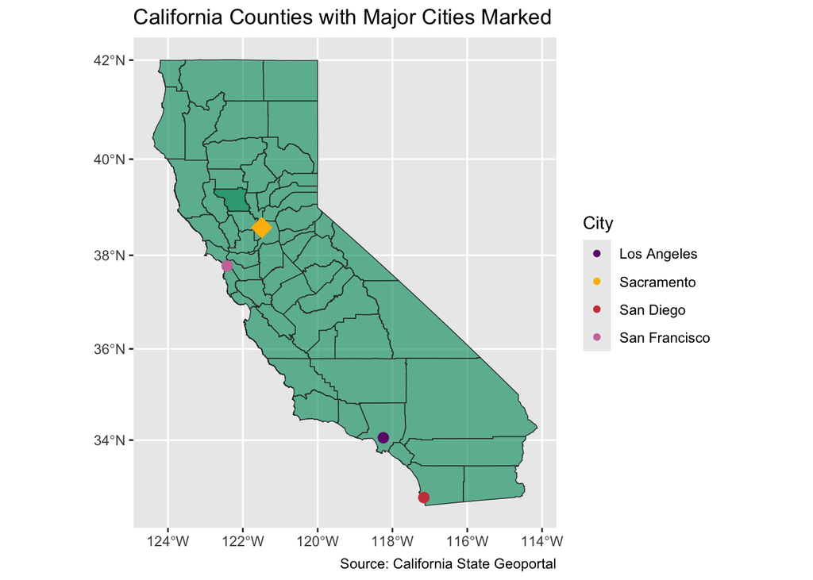

#### Question 5 [1 point]:

Your stakeholders point out that you have forgotten San Jose, one of the most populated cities in California! They ask you to go back to the map and add it on.

**Hint 1**: The coordinates of San Jose are 37.3387° N, 121.8853° W **Hint 2**: Don’t forget to add a `cityType` for San Jose! **Hint 3**: Don’t forget to add a skittles color for San Jose in `scale_color_manual`!

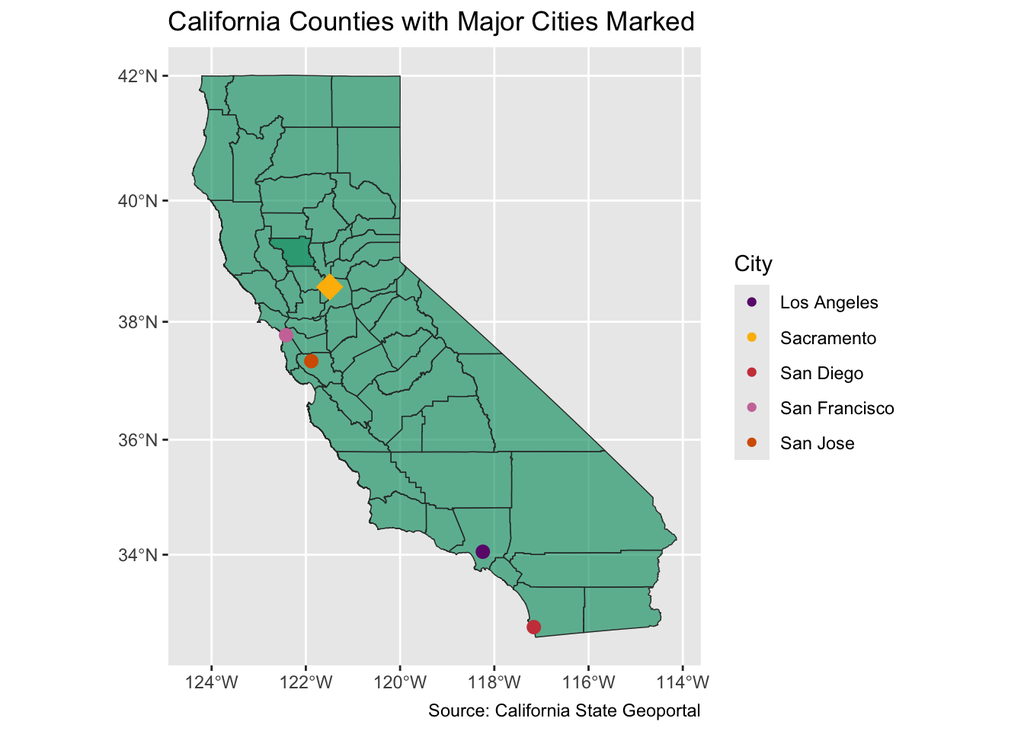

```r
## Create a cities data frame with coordinates, now including San Jose
cities <- data.frame(
  city = c("Sacramento", "San Diego", "Los Angeles", "San Francisco", "San Jose"),
  lon = c(-121.4944, -117.1611, -118.2437, -122.4194, -121.8853),
  lat = c(38.5816, 32.7157, 34.0522, 37.7749, 37.3387),
  cityType = c("capital", "major", "major", "major", "major")
)

## Convert to shapefile object
cities_sf <- st_as_sf(cities, coords = c("lon", "lat"), crs = 4326)

## Plot California counties with city points, including San Jose
ggplot(data = cali_sf) +
  geom_sf(
    fill = skittles[6],
    color = "gray20",
    linewidth = 0.25,
    alpha = 0.65
  ) +
  coord_sf(expand = FALSE) +
  geom_sf(
    data = cities_sf,
    aes(color = city, shape = cityType, size = cityType)
  ) +
  scale_shape_manual(values = c(capital = 18, major = 16), guide = "none") +
  scale_size_manual(values = c(capital = 6, major = 3), guide = "none") +
  scale_color_manual(values = skittles[1:5], name = "City") +
  labs(
    title = "California Counties with Major Cities Marked",
    caption = "Source: California State Geoportal"
  )
```

## 2.4 Joining shapefiles with a tibble or dataframe

As mentioned above, the `sf_read()` function from the `sf` package loads your shapefile as a `tibble`, which makes life much easier for you when dealing with shapefiles. It also means you can easily join your shapefiles with other tibbles / dataframes, like the ones we’ve imported of mortality data. Let’s briefly breakdown what your process to do this is going to look like:

**Our Process:**

1. Rename the **County** column so it matches the shapefile
2. Summarize the data by **Year** so you can visualize the annual trends
3. Join the two tibbles by `COUNTY_NAME`
4. Make sure to turn the joined tibble **back into a shapefile** using the `st_as_sf()` function, otherwise it will fail. The join will convert it into a structure that is no longer a shapefile, so you have to back-convert it to a shapefile!

#### Question 6 [1 point]:

Annotate the following code chunk with comments to make sure you understand what you are doing here. **HINT**: refer back to the earlier tables with the data descriptions to help you understand the data better!

```r
## Start with the totalDeaths dataset because it contains the county-level
## mortality counts that we want to visualize on a map
mortality_sf <- totalDeaths %>%
  ## Rename the County column so that it matches the county name
  ## column in the California shapefile and can be joined correctly
  rename(COUNTY_NAM = County) %>%
  ## Group the mortality data by county, year, and month so that
  ## deaths can be summarized within each county-time period
  group_by(COUNTY_NAM, Year, Month) %>%
  ## Calculate the total number of deaths for each county-year-month
  ## combination while ignoring missing values
  summarise(totalDeaths = sum(totalDeaths, na.rm = TRUE)) %>%
  ## Join the mortality data to the California county shapefile using
  ## COUNTY_NAM as the matching variable. The relationship is set to
  ## "many-to-many" because multiple mortality records exist for each
  ## county (different months and years), and the shapefile may also
  ## contain multiple geometry features for a county.
  full_join(cali_sf, by = "COUNTY_NAM", relationship = "many-to-many") %>%
  ## Convert the joined dataset back into an sf object so it retains
  ## its spatial geometry and can be mapped and analyzed spatially
  st_as_sf()
```

#### Question 7A [0.5 points]:

What does `st_join()` do? Could you have executed the join with `st_join()` instead of `full_join()` here? Why or why not?

> The st_join() function performs a spatial join by matching features based on their geographic locations and spatial relationships rather than a common column. For example, it can determine whether a point falls within a polygon or whether two geographic features overlap. In this case, st_join() would not be the most appropriate choice because the mortality data and the California shapefile share a common county name variable (COUNTY_NAM). The goal is to join the datasets using county names rather than spatial relationships. Therefore, full_join() is more appropriate because it matches records using the shared county identifier.

#### Question 7B [0.5 points]:

This question has three subparts.

1. How many features are there in `mortality_sf`?

```r
nrow(mortality_sf)
```

```
## [1] 2596
```

2. Why are there so many more than in `cali_sf`? > There are 2,596 features in mortality_sf. There are many more features because the mortality dataset contains multiple observations for each county across different months and years. When the mortality data were joined to the shapefile, the county geometries were repeated for each county-month-year observation. As a result, the number of rows increased substantially from the original shapefile.
3. How many counties are there now in `COUNTY_NAM`? (Hint: Use `unique()` or `n_distinct()` to help you get the true number!) Why is it different from the number you saw in Question 2?

```r
n_distinct(mortality_sf$COUNTY_NAM)
```

```
## [1] 58
```

> There are 58 unique counties in COUNTY_NAM. This differs from the 59 geometry features observed in Question 2 because Question 2 counted spatial features, while this question counts unique county names. One county was represented by more than one geometry feature in the shapefile, which is why there were 59 features but only 58 unique counties. After the join, the counties appear many times due to repeated monthly and yearly observations, but the number of unique counties remains 58.